# Lab 09: Modeling Data 2

Ednita Tavarez-Jimenez

## Chi-square Tests 1

**Q1: State the null hypothesis of the Chi-square test. Make sure you state the null hypothesis in terms of Brown Creeper presence/absence and edge/interior habitats.**

**Q2: Consider the results of your test and explain whether you think that Brown Creepers show a significant habitat preference. Make sure your use the output of your statistical test to support your answer.**

My null hypotheses is rejected because the Brown Crepper did show a preference in habitat.

```r
require(here)
birds = read.csv(here("data", "bird.sta.csv"))
hab = read.csv(here("data", "hab.sta.csv"))
birdhab = merge(
  birds,
  hab, by=c("basin", "sub", "sta"))

# Create a contingency table for edge/interior and brown creeper presence/absence
table(
  birdhab$s.edge,
  birdhab$BRCR > 0)
```

```
##
##     FALSE TRUE
##   E   144   29
##   I   559  314
```

```r
# set the presence to be in the first column
br_creeper_table = table(
  birdhab$s.edge,
  birdhab$BRCR > 0)[, 2:1]

br_creeper_table
```

```
##
##     TRUE FALSE
##   E   29   144
##   I  314   559
```

```r
br_creeper_table = matrix(c(29, 314, 144, 559), nrow=2)
rownames(br_creeper_table) = c("present", "absent")
colnames(br_creeper_table) = c("old", "young")
chisq_BRCR = chisq.test(br_creeper_table)
chisq_BRCR
```

```
##
##  Pearson's Chi-squared test with Yates' continuity correction
##
## data:  br_creeper_table
## X-squared = 23.3, df = 1, p-value = 1.386e-06
```

##Building Models for ANOVA

```r
require(palmerpenguins)
fit_fl_sp =
  lm(
    formula = flipper_length_mm ~ species,
    data = penguins)
```

**Q3: Show the R-code you can use to create a model fit (call it fit_species) of penguin body mass as predicted by penguin species.**

```r
fit_species <-  lm(
    formula = body_mass_g ~ species,
    data = penguins)
```

**Q4:Show the R-code you can use to create a model fit (call it fit_sex) of penguin body mass as predicted by sex.**

```r
fit_sex <-  lm(
    formula = body_mass_g ~ sex,
    data = penguins)
```

**Q5: Show the R-code you can use to create a model fit (call it fit_both) of penguin body mass as predicted by species and sex. This should be an interactive model, i.e. it should include a sex:species interaction.**

```r
fit_both <- lm(
    formula = body_mass_g ~ sex*species,
    data = penguins)
```

## Homogeneity Assumption: Graphical

**Q6: Include a conditional boxplot corresponding to the grouping structure in your fit_species model.

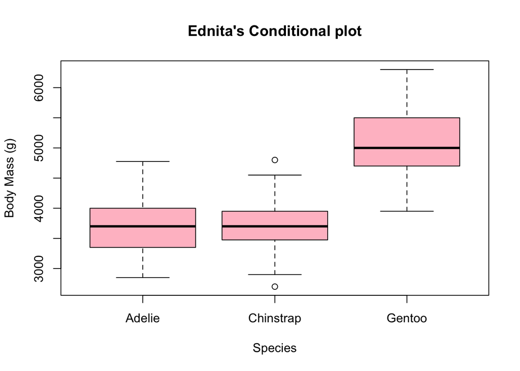

```r
boxplot(body_mass_g ~ species, main = "Ednita's Conditional plot", xlab = "Species", ylab = "Body Mass (g)", data = penguins, col = "pink")
```

**Q7: Include a conditional boxplot corresponding to the grouping structure in your fit_sex model.**

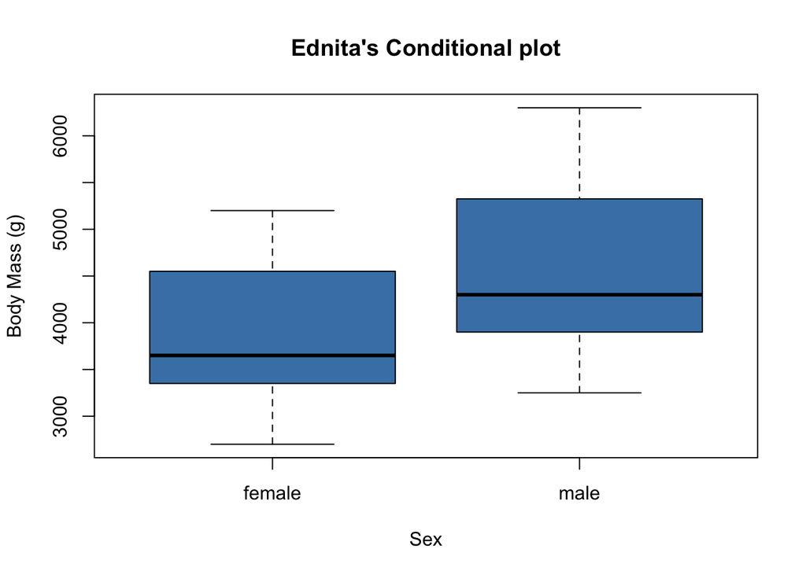

```r
boxplot(body_mass_g ~ sex, main = "Ednita's Conditional plot", xlab = "Sex", ylab = "Body Mass (g)", data = penguins, col = "steelblue")
```

**Q8: Include a conditional boxplot corresponding to the grouping structure in your fit_both model.**

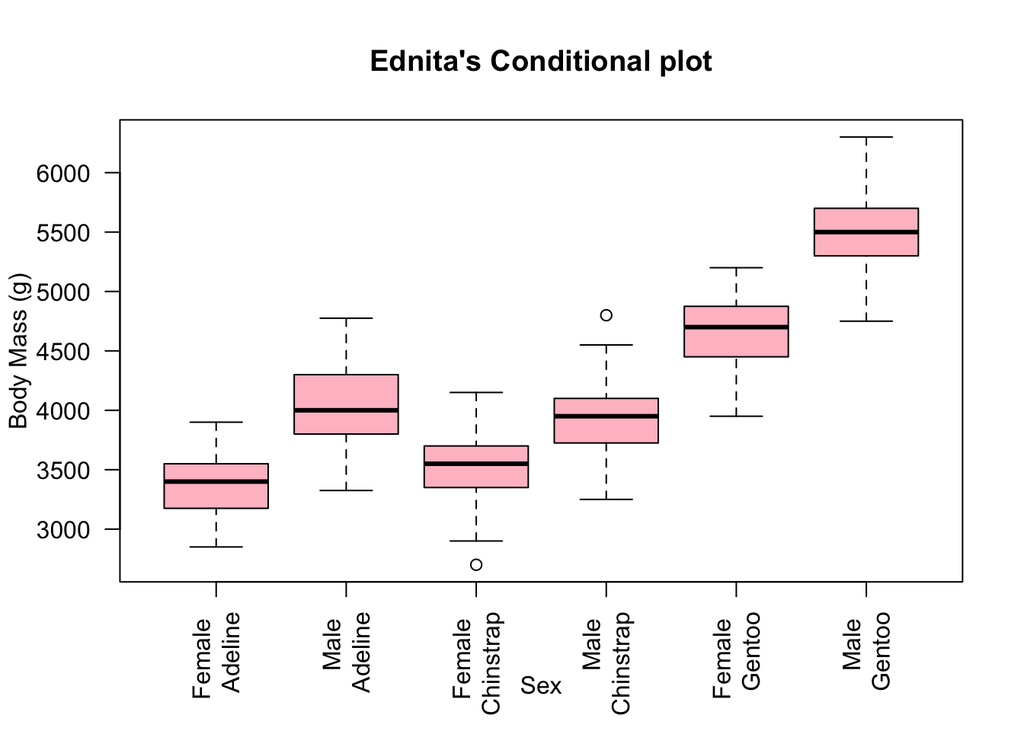

```r
boxplot(body_mass_g ~ sex*species, main = "Ednita's Conditional plot", xlab = "Sex", ylab = "Body Mass (g)", data = penguins, col = "pink",  names = c("Female \n Adeline", "Male \n Adeline", "Female \n Chinstrap", "Male \n Chinstrap", "Female \n Gentoo", "Male \n Gentoo"), las = 2)
```

**Q9: Based on the shapes of the boxes, which of the models (if any) do you think may have problems fulfilling the homogeneity assumption?**

I dont think any of the models have trouble fulfilling the homogeneity assumption.

## Homogeneity Assumption: Barlett Test 1

**Q10: State the null hypothesis of the Bartlett test.**

There will not be a difference in homogeneity between the body mass g with species and sex in my models.

**Q11: What was the p-value from the Bartlett test of homogeneity for observations grouped by species? You can round your answer to 4 decimal digits.**

The p-value from the Bartlett test of homogeneity for observation grouped by species is 0.05005

```r
bartlett.test(body_mass_g ~ species, data = penguins)
```

```
##
##  Bartlett test of homogeneity of variances
##
## data:  body_mass_g by species
## Bartlett's K-squared = 5.9895, df = 2, p-value = 0.05005
```

**Q12: What was the p-value from the Bartlett test of homogeneity for observations grouped by sex? You can round your answer to 4 decimal digits.**

The p-value from the Bartlett test of homogeneity for observations grouped by sex is .03194.

```r
bartlett.test(body_mass_g ~ sex, data = penguins)
```

```
##
##  Bartlett test of homogeneity of variances
##
## data:  body_mass_g by sex
## Bartlett's K-squared = 4.6017, df = 1, p-value = 0.03194
```

## Homogeneity Assumption: Bartlett Test 2

**Q13: What was the p-value from the Bartlett test of homogeneity for observations grouped by both factors? You can round your answer to 4 decimal digits.**

The p-value from the bartlett test of homogeneity for observations groupd by both factors is 0.1741.

```r
dat_groups = aggregate(
  body_mass_g ~ sex*species,
  data = penguins,
  FUN = c)
str(dat_groups)
```

```
## 'data.frame':    6 obs. of  3 variables:
##  $ sex        : Factor w/ 2 levels "female","male": 1 2 1 2 1 2
##  $ species    : Factor w/ 3 levels "Adelie","Chinstrap",..: 1 1 2 2 3 3
##  $ body_mass_g:List of 6
##   ..$ : int  3800 3250 3450 3625 3200 3700 3450 3325 3400 3800 ...
##   ..$ : int  3750 3650 4675 3800 4400 4500 4200 3600 3950 3800 ...
##   ..$ : int  3500 3525 3950 3250 4150 3800 3700 3575 3700 3450 ...
##   ..$ : int  3900 3650 3725 3750 3700 3775 4050 4050 3300 4400 ...
##   ..$ : int  4500 4450 4550 4800 4400 4650 4650 4200 4150 4800 ...
##   ..$ : int  5700 5700 5400 5200 5150 5550 5850 5850 6300 5350 ...
```

```r
body_mass_g <- dat_groups$body_mass_g

bartlett.test(body_mass_g, data = dat_groups)
```

```
##
##  Bartlett test of homogeneity of variances
##
## data:  body_mass_g
## Bartlett's K-squared = 7.6908, df = 5, p-value = 0.1741
```

**Q14: Based on the results of the Bartlett tests, do you anticipate any issues with heterogeneity in any of the models? Make sure you justify your response with the results of your tests.**

##Florida Trees

**Q15: Perform a graphical exploration of the dataset. Create the following plots and include them in your report. You may create separate figures, or combine them into one multi-panel figure. A bar plot of counts of trees in each probability of failure class (column Probability of Failure, A barplot of the counts of trees in each of the failure classes (column Failure_Standardized), A histogram of DBH, A scatterplot of DBH (x-axis) and tree height (y axis)**

```r
require(here)
dat_fl = read.csv(here("data", "trees_FL.csv"))

table(dat_fl$ProbabilityofFailure)
```

```
##
##    1    2    3    4
## 1407  889  627  116
```

```r
table(dat_fl$Failure_Standardized)
```

```
##
## branch   none  whole
##    438   2389    219
```

```r
table(dat_fl$DBH_in)
```

```
##
##  0.1  0.2  0.3  0.4  0.5  0.7 0.75  0.8    1  1.1  1.2  1.3  1.4  1.5  1.6  1.7
##   14   26    6    1   48    1    1   23  102    3   17   22    3   65    9    6
##  1.8  1.9    2  2.1  2.2  2.3  2.4  2.5  2.6  2.7  2.8  2.9    3  3.1  3.2  3.3
##   28    9   59   12   18   16    6   35   11    9   15    8   63    7   12    7
##  3.4  3.5  3.6  3.7  3.8  3.9    4  4.1  4.2  4.3  4.4  4.5  4.6  4.7  4.8  4.9
##   10   24   11    9   12   10   37   13   23   21   10   27   13   16   15   10
##    5  5.1  5.2  5.3  5.4  5.5  5.6  5.7  5.8  5.9    6  6.1  6.2  6.3  6.4  6.5
##   25   10   11   12    5   14    8   13   18    8   21   17   19   10    7   16
##  6.6  6.7  6.8  6.9    7  7.1  7.2  7.3  7.4  7.5  7.6  7.7  7.8  7.9    8  8.1
##    7    9   12    6   17    7   10   10    8    9    7    3    7    1   20    6
##  8.2  8.3  8.4  8.5  8.6  8.7  8.8  8.9    9  9.1  9.2  9.3  9.4  9.5  9.6  9.7
##    5    5   11   15    5    6   12    9   11    6    7   10    5   14    6    8
##  9.8  9.9   10 10.1 10.2 10.3 10.4 10.5 10.6 10.7 10.8 10.9   11 11.1 11.2 11.3
##   14    6   14    2   12    8    1   10    8    6   12    8   10    3   10    8
## 11.4 11.5 11.6 11.7 11.8 11.9   12 12.1 12.2 12.3 12.4 12.5 12.6 12.7 12.8 12.9
##    9   12    5   12    4    2   14    4    5    8    4   11    5    5    6    6
##   13 13.1 13.2 13.3 13.4 13.5 13.6 13.7 13.8 13.9   14 14.1 14.2 14.3 14.4 14.5
##   28   10    5    8   12    9    9    9    4    8   18    8    8    6    5   11
## 14.6 14.7 14.8 14.9   15 15.1 15.2 15.3 15.4 15.5 15.6 15.7 15.8 15.9   16 16.1
##    4    6   13    6   11    5    7   11    8   15    4    7    6    7   18    6
## 16.2 16.3 16.4 16.5 16.6 16.7 16.8 16.9   17 17.1 17.2 17.3 17.4 17.5 17.6 17.7
##    9    7    6   13    6    6    9    7   14    5    4    8    9   13    8    7
## 17.8 17.9   18 18.1 18.2 18.3 18.4 18.5 18.6 18.7 18.8 18.9   19 19.1 19.2 19.3
##    8    3   12    7    6    5    4   14    4    4    6    4   10    6    8    9
## 19.4 19.5 19.6 19.7 19.8 19.9   20 20.1 20.2 20.3 20.4 20.5 20.6 20.7 20.8 20.9
##    8   12    6    5    7    2   21    1    2    5    2    6    8    6    9    2
##   21 21.1 21.2 21.3 21.4 21.5 21.6 21.7 21.8 21.9   22 22.1 22.2 22.3 22.4 22.5
##   16    4   10    6    7    8    4    2    8    6   11    2    5    5    6    8
## 22.6 22.7 22.8 22.9   23 23.1 23.2 23.3 23.4 23.5 23.6 23.7 23.8 23.9   24 24.1
##    3    3   12    4    7    4    6    3    4    6    3    4    8    1   14    6
## 24.2 24.3 24.4 24.5 24.6 24.7 24.8 24.9   25 25.1 25.2 25.3 25.4 25.5 25.6 25.7
##    6    5    9    9    4    3    4    1    8    2    5    9    6    5    3    4
## 25.8 25.9   26 26.1 26.2 26.3 26.4 26.5 26.6 26.7 26.8 26.9   27 27.1 27.2 27.3
##    5    4   11    2    5    3    2    8    2    6    3    2   10    4    2    1
## 27.4 27.5 27.6 27.7 27.8 27.9   28 28.1 28.2 28.3 28.5 28.7 28.8 28.9   29 29.1
##    4    4    4    2    3    4    6    2    5    2    8    2    3    1    4    3
## 29.2 29.3 29.4 29.5 29.6 29.7 29.8 29.9   30 30.1 30.2 30.3 30.4 30.5 30.6 30.7
##    3    3    5    8    2    1    2    2    5    2    3    3    1    3    1    2
## 30.8   31 31.2 31.4 31.5 31.6 31.8   32 32.1 32.2 32.3 32.5 32.6 32.7 32.8 32.9
##    2    7    1    4    7    2    2   13    3    3    2    6    2    4    1    1
##   33 33.1 33.2 33.3 33.4 33.5 33.6 33.7 33.8 33.9   34 34.2 34.3 34.4 34.5 34.8
##    6    1    6    3    1    3    1    1    1    4    5    1    2    1    2    1
##   35 35.3 35.5 35.6 35.8 35.9   36 36.1 36.3 36.4 36.5 36.6 36.7 36.8 36.9   37
##    6    2    3    1    1    1    7    4    1    1    4    3    1    2    1    3
## 37.1 37.2 37.3 37.4 37.5 37.6 37.9   38 38.2 38.3 38.4 38.5 38.6 38.7 38.8 38.9
##    1    2    2    1    3    2    2    6    2    1    1    2    1    1    1    1
##   39 39.3 39.5 39.6 39.8   40 40.1 40.2 40.3 40.4 40.5 40.7 40.9   41 41.1 41.2
##    5    2    3    1    2    5    2    3    1    1    1    2    1    4    1    2
## 41.3 41.4 41.5 41.6 41.8 41.9   42 42.3 42.4 42.5 42.6 42.7 42.8   43 43.2 43.4
##    1    1    1    1    2    1    2    2    2    3    1    1    1    2    1    2
## 43.5 43.8 43.9   44 44.2 44.4 44.6 44.7   45 45.1 45.3 45.6 45.7 45.8   46 46.5
##    4    1    2    2    2    1    1    1    1    1    1    1    1    1    2    3
##   47 47.2 47.5 47.8   48 48.5 48.6   49 49.4 49.5 49.7 49.8 50.2 50.4   51 51.2
##    5    1    2    1    2    1    1    2    1    1    1    2    2    1    2    1
## 51.8 51.9 52.2 52.5   53   54 54.2 55.4 55.8   56 56.8   57   58 58.2 58.5   60
##    1    1    1    1    1    2    1    1    1    1    1    1    1    1    1    1
## 63.3 63.5 63.6   67 68.7 69.3   74
##    1    1    1    1    1    1    1
```

```r
table(dat_fl$HeighttoTop_ft)
```

```
##
##  2.5    3  3.5    4  4.5    5  5.5    6  6.5  6.7    7  7.5    8  8.5    9  9.5
##    1    3    1    9   10   14   17   31   26    1   37   34   35   22   41   39
##   10 10.5   11 11.5   12 12.5   13 13.5   14 14.5   15 15.5   16 16.5   17 17.5
##   48   28   32   23   64   34   35   22   31   18   64   12   28   25   30   22
## 17.9   18 18.5   19 19.5   20 20.5 20.9   21 21.5   22 22.5 22.6   23 23.5   24
##    1   43   35   26   25   48   27    1   54   33   37   36    1   40   29   35
## 24.5   25 25.5   26 26.5   27 27.5   28 28.5   29 29.5 29.6   30 30.5   31 31.5
##   28   42   28   20   25   31   25   17   26   31   17    1   33   24   23   22
##   32 32.5   33 33.5   34 34.5   35 35.5   36 36.5   37 37.5   38 38.5   39 39.5
##   26   36   25   24   32   14   31   22   30   27   25   29   27   21   29   28
## 39.9   40 40.5   41 41.5   42 42.5   43 43.5   44 44.5   45 45.5   46 46.5   47
##    1   29   25   22   17   26   27   26   25   22   26   32   24   15   21   25
## 47.5   48 48.5   49 49.5   50 50.5   51 51.1 51.5   52 52.5   53 53.5   54 54.5
##   24   40   27    8   30   21   23   17    1   17   14   17   19   18   14   19
##   55 55.5   56 56.5   57 57.5   58 58.5   59 59.5   60 60.5   61 61.5   62 62.5
##   16   12   16    6   15   16    5   13    8    7   15    5    3    9   10    4
##   63 63.3 63.5   64 64.5   65 65.5   66 66.5   67 67.5   68 68.5   69 69.5   70
##    6    1    4    4    6   11   10    3    7    6    3    3    1    5    1    3
## 70.5   71   72 72.5   73   74   75 75.5
##    1    2    2    2    3    1    1    1
```

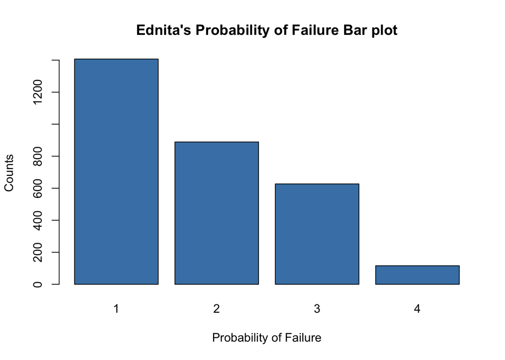

```r
fit_trees <-  lm(
    formula = DBH_in ~ HeighttoTop_ft,
    data = dat_fl)


barplot(table(dat_fl$ProbabilityofFailure),
  main = "Ednita's Probability of Failure Bar plot",
  xlab = "Probability of Failure",
  ylab = "Counts",
  col = "steel blue"
)
```

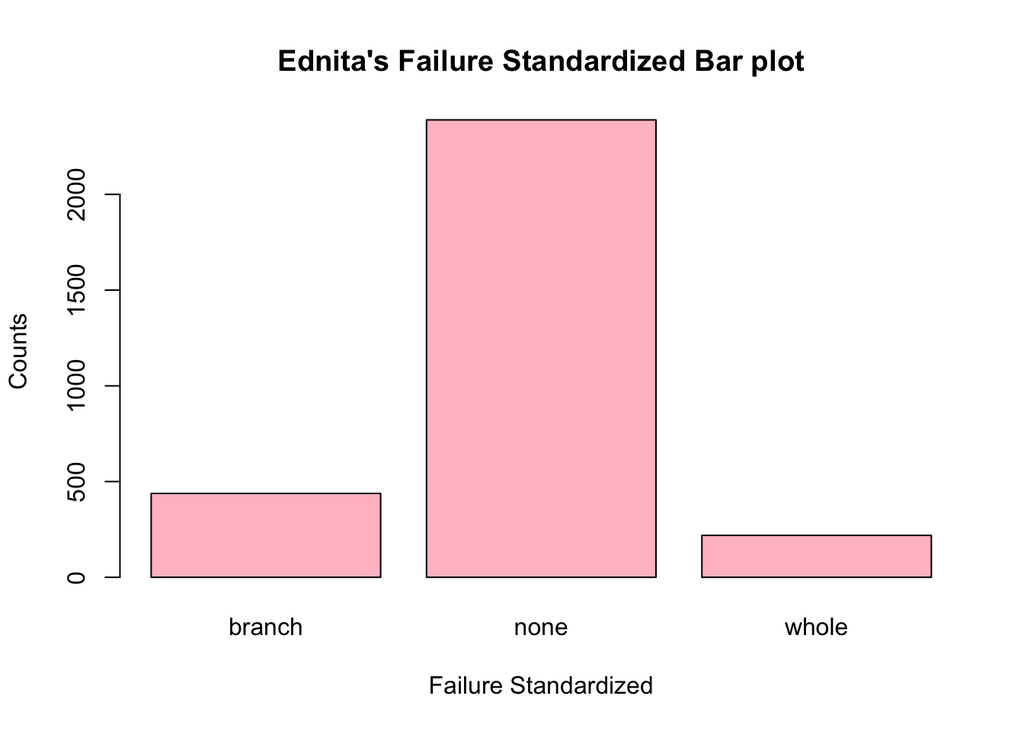

```r
barplot(table(dat_fl$Failure_Standardized),
  main = "Ednita's Failure Standardized Bar plot",
   xlab = "Failure Standardized",
  ylab = "Counts",
  col = "pink"
)
```

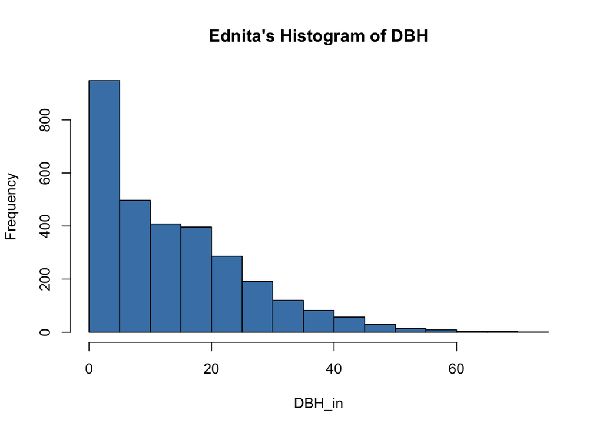

```r
hist(dat_fl$DBH_in, main = "Ednita's Histogram of DBH",xlab = "DBH_in", col = "steel blue")
```

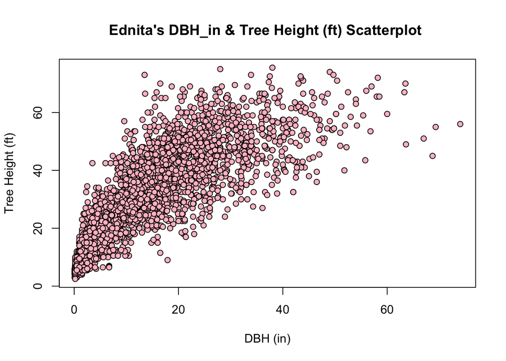

```r
plot(
  HeighttoTop_ft ~ DBH_in,
  data = dat_fl,
  main = "Ednita's DBH_in & Tree Height (ft) Scatterplot ",
  xlab = "DBH (in)",
  ylab = "Tree Height (ft)",
  pch = 21, col = 1, bg = "pink"
)
```

##Florida Trees: Compare Distributions

**Q16: State the null hypothesis for the Kolmogorov-Smirnov test. Your answer should be in terms of the DBH of the two groups of trees.**

The null hypothesis of the Kolmogorov - Smirnov is that the two data set values are from the same continuous distribution.

**Q17: What was the p-value of the test? Based on the evidence, do you think the distribution of DBH is the same for the two groups?**

The p-value is 0.02125.

```r
dat_branch <- subset(dat_fl, Failure_Standardized == "branch")
dat_none <- subset(dat_fl, Failure_Standardized == "none")
dat_whole <- subset(dat_fl, Failure_Standardized == "whole")

ks.test(dat_whole$DBH_in, dat_none$DBH_in)
```

```
##
##  Two-sample Kolmogorov-Smirnov test
##
## data:  dat_whole$DBH_in and dat_none$DBH_in
## D = 0.10643, p-value = 0.02125
## alternative hypothesis: two-sided
```

## Challenge

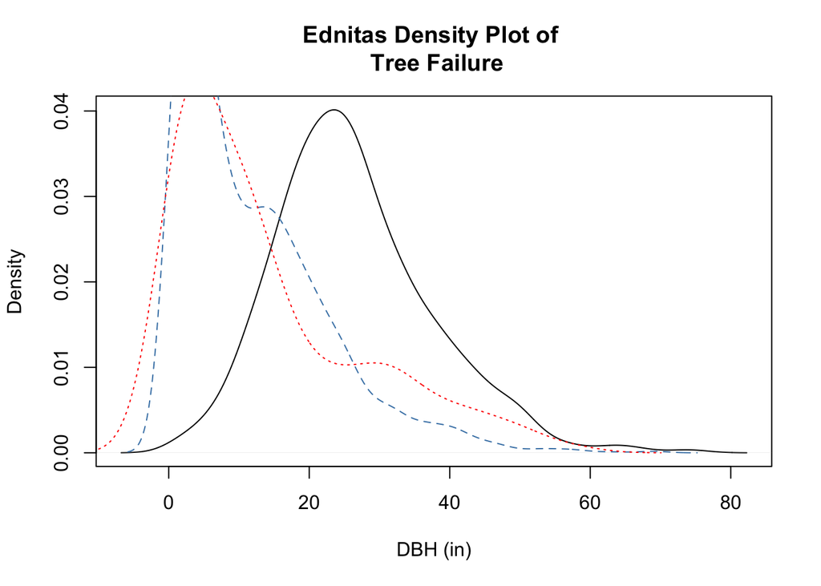

```r
plot(density(dat_branch$DBH_in), main = "Ednitas Density Plot of \n Tree Failure", lty = 1, col = "black", xlab = "DBH (in)")

lines(density(dat_none$DBH_in),
  lty=2,
  add=TRUE, col = "steelblue")
  lines(density(dat_whole$DBH_in),
  lty=3 ,
  add=TRUE, col = "red")
  legend(
  x = 0.4, y = 0.4,
  lty = c(1, 2, 3),
  legend = c("branch", "none", "whole"),
  title = "Failure Type")
```

##Florida Trees Correlations

**Q18: Qualitatively describe the shape of the relationship between DBH and height. Is it linear? Curved? Monotonic?**

The graph is curved and shows that as the DBH increase so does the hight of the tree.

**Q19: Given your answer to the previous question, which type of correlation coefficient is most appropriate?**

**Q20: What is the p-value? Do you conclude that the two variables are significantly correlated?**

```r
t.test(dat_whole$DBH_in, dat_none$DBH_in, paired = FALSE)
```

```
##
##  Welch Two Sample t-test
##
## data:  dat_whole$DBH_in and dat_none$DBH_in
## t = 2.2841, df = 243.16, p-value = 0.02323
## alternative hypothesis: true difference in means is not equal to 0
## 95 percent confidence interval:
##  0.2925928 3.9599703
## sample estimates:
## mean of x mean of y
##  13.74817  11.62189
```

##Florida Trees: Risk Rating

**Q21: What was the value of the test statistic (X-squared)? What was the corresponding p-value?**

The value of the test statistic is 202.65 and the corresponding p-value is 2.2e-16.

```r
dat_fl$fail = factor(dat_fl$Failure_Standardized != "none")

levels(dat_fl$fail) = c("No Fail", "Fail")

fl_table_2 = table(
  dat_fl$ProbabilityofFailure,
  dat_fl$fail)
fl_table_2
```

```
##
##     No Fail Fail
##   1    1239  168
##   2     670  219
##   3     421  206
##   4      53   63
```

```r
rownames(fl_table_2) = c("1", "2", "3", "4")
colnames(fl_table_2) = c("Fail", "No Fail")
chisq_fl_table_2 = chisq.test(fl_table_2)
chisq_fl_table_2
```

```
##
##  Pearson's Chi-squared test
##
## data:  fl_table_2
## X-squared = 202.65, df = 3, p-value < 2.2e-16
```

**Q22: What is the value of the chi-square residual (rounded to the nearest whole number) for the count of failures in probability category 1?

```r
round(chisq_fl_table_2$observed - chisq_fl_table_2$expected,digits = 1)
```

```
##
##       Fail No Fail
##   1  135.7  -135.7
##   2  -27.1    27.1
##   3  -70.7    70.7
##   4  -38.0    38.0
```

**Q23: Were there more, or fewer, tree failures than expected by chance in failure probability category #1?**

**Q24: Were there more, or fewer, tree failures than expected by chance in failure probability category #4?**

**Q25: Given your answers to the previous two questions, do you conclude that the probability of failure rating system is effective?**

I conclude that the probability of failure rating system is effected. It shows if there are more, or less tree failures.